# Stats confidence mini experiment

The idea is to look at gender gaps in anxiety & self-efficacy in statistics as a function of instructor gender.

Broadly, these are predictions drawn from the stereotype threat literature demonstrating the effect of situation-specific anxiety stemming from a fear of confirming an existing negative stereotype.

The hypothesis is that a male instructor’s presence may serve as an implicit reminder of stereotypes about women students’ abilities in stats/maths/STEM subjects.

By contrast, female instructors may serve as ‘role models’ and successfully alleviate anxieties about the prospect of confirming a stereotype.

To have an improved framework of comparison, I am also looking at domains where obvious stereotypes don’t exist or maybe advantage women: confidence about doing well in students’ respective social science course, and confidence in essay writing skills.

# Procedure

POL1008 ‘Introduction to Social Data’ module for many is first exposure to (university-level) statistics. 170 students are randomly assigned to 5 labs running biweekly over the course of Term 1.

For the very first lab meetings, 5 ‘instructors’ are sent randomly to address these groups, consisting of an introduction and the announcement of a poll about skills and confidence.

Following questions about statistics, social science, and essay writing skills-confidence, the distribution of responses were shown for group-level reflection. If instructor spotted high numbers of timid answers, they had the chance to address and say this session would help to strengthen confidence.

Ideally, a large N of instructors would be split between male and female, with enough variation within instructor gender to build a better case for gender effects as average treatment effects.

Rather, across five groups, 2 instructors were male and 3 were female, all aged 27–33, formally affiliated with the Exeter Q-Step Centre in varying ways that they could reflect on at the introduction (meant to demonstrate competence).

Following the three dependent measures, gender, and GSCE math grade, students were asked for consent to participate in this study to analyse gender gaps in statistical confidence, with an extra option to participate in follow-up interviews.

# Data

Chunk below loads data and libraries.

```r
library(data.table)
library(MCMCglmm)
library(lattice)

d <- data.table(read.csv("pol1008.csv"))

d <- d[consent!="n",,] # removing respondents who did not give consent.
```

Overview of respondent N per instructor & of respondent N per combination of participant gender x instructor gender (1 stands for men and 2 for women).

```r
d[,.N,by=instructor]
```

```
##    instructor  N
## 1:          1 22
## 2:          2 27
## 3:          3 27
## 4:          4 22
## 5:          5 21
```

```r
d[!is.na(gender),.N,by=list(gender,instructor_gender)][order(gender,instructor_gender)]
```

```
##    gender instructor_gender  N
## 1:      1                 1 19
## 2:      1                 2 20
## 3:      2                 1 27
## 4:      2                 2 48
```

Shows notable imbalance on the number of women respondents under female instructors, stems from last instructor working with an unusual group of 17 women and 3 men only.

Dependent variables measured on ordinal scales where 1 indicates ‘least confident’, 4 indicates ‘most confident’, - about doing well in statistics module:

```r
table(d$stats)
```

```
##
##  1  2  3  4
## 21 53 39  1
```

- about doing well in social science course:

```r
table(d$ssci)
```

```
##
##  1  2  3  4
##  3 28 79  4
```

- about having the essay writing skills to do well in their degree programme:

```r
table(d$essay)
```

```
##
##  1  2  3  4
## 13 53 48  3
```

GSCE math grade used in extended model to control for differences in ability, coded 1 if highest grade (A*) and 6 if lowest (U).

```r
table(d$math)
```

```
##
##  1  2  3  4  5  6
## 33 45 21 16  1  1
```

# Bivariate tests

Exploring the odds of selecting either level of confidence (DV) by student gender (IV) broken down by instructor gender.

Women are expected to be less likely to be confident than men only under lead by male instructors, and there should be no gender-confidence association under female instructors.

## Statistics module

- significant gender gaps prevail in male instructor group. Discarding the two extremes, women are over 6 times more likely to select a ‘non-confident’ answer than a ‘confident’ answer, relative to men. There were no women selecting the ‘very confident’ extreme, but over twice as many women as men selected the ‘not confident at all’ extreme:

```r
t1_m <- table(d[instructor_gender==1,,]$stats,d[instructor_gender==1,,]$gender)
round(prop.table(t1_m),2)
```

```
##
##        1    2
##   1 0.07 0.18
##   2 0.11 0.33
##   3 0.20 0.09
##   4 0.02 0.00
```

```r
chisq.test(t1_m)
```

```
##
##  Pearson's Chi-squared test
##
## data:  t1_m
## X-squared = 8.7456, df = 3, p-value = 0.03287
```

- there are no comparable gaps under female instructors. While women are, descriptively, still 3 time more likely to be less confident than confident suggesting that the gap reduced to about half & failing to reach statistical significance.

```r
t1_w <- table(d[instructor_gender==2,,]$stats,d[instructor_gender==2,,]$gender)
round(prop.table(t1_w),2)
```

```
##
##        1    2
##   1 0.03 0.11
##   2 0.09 0.39
##   3 0.16 0.22
```

```r
chisq.test(t1_w)
```

```
##
##  Pearson's Chi-squared test
##
## data:  t1_w
## X-squared = 3.5118, df = 2, p-value = 0.1728
```

## Social science course

- there is no significant gender gap in confidence under either instructor gender if asked about social science course,

```r
t2_m <- table(d[instructor_gender==1,,]$ssci,d[instructor_gender==1,,]$gender)
round(prop.table(t2_m),2)
```

```
##
##        1    2
##   2 0.09 0.15
##   3 0.28 0.41
##   4 0.04 0.02
```

```r
chisq.test(t2_m)
```

```
##
##  Pearson's Chi-squared test
##
## data:  t2_m
## X-squared = 0.91282, df = 2, p-value = 0.6336
```

- though women do appear to be somewhat more confident under a female instructor.

```r
t2_w <- table(d[instructor_gender==2,,]$ssci,d[instructor_gender==2,,]$gender)
round(prop.table(t2_w),2)
```

```
##
##        1    2
##   1 0.02 0.02
##   2 0.10 0.16
##   3 0.17 0.54
```

```r
chisq.test(t2_w)
```

```
##
##  Pearson's Chi-squared test
##
## data:  t2_w
## X-squared = 1.4506, df = 2, p-value = 0.4842
```

## Essay writing skills

- there is no comparable gender gap in confidence under either instructor gender if asked about essay writing skills. Either under male instructors,

```r
t3_m <- table(d[instructor_gender==1,,]$essay,d[instructor_gender==1,,]$gender)
round(prop.table(t3_m),2)
```

```
##
##        1    2
##   1 0.02 0.07
##   2 0.17 0.24
##   3 0.15 0.28
##   4 0.07 0.00
```

```r
chisq.test(t3_m)
```

```
##
##  Pearson's Chi-squared test
##
## data:  t3_m
## X-squared = 5.0347, df = 3, p-value = 0.1693
```

- or under female instructors.

```r
t3_w <- table(d[instructor_gender==2,,]$essay,d[instructor_gender==2,,]$gender)
round(prop.table(t3_w),2)
```

```
##
##        1    2
##   1 0.03 0.09
##   2 0.14 0.35
##   3 0.12 0.27
```

```r
chisq.test(t3_w)
```

```
##
##  Pearson's Chi-squared test
##
## data:  t3_w
## X-squared = 0.11264, df = 2, p-value = 0.9452
```

# Multilevel MCMC models

The chunkcs below fit three multilevel models, per dependent variable, fit via MCMC, where:

- the reasoning behind Bayesian estimation is more technical than philosophical: (a) the availability of the posterior distribution without having to simulate it, as I’d need to in other multilevel packages to get confidence intervals, (b) readily available for an ordered probit regression, other packages don’t offer a good solution for ordinal dependent variables;
- random ‘effects’ are the 5 instructors/groups, this is also meant to capture all unobserved variation across these 5 groups due to different timing of sessions over two weeks, different timing during the day, attendance rates, gender splits etc.;
- individual-level fixed effect is gender, 1 men 2 women, interacted with
- group-level ‘instructor gender’, 1 male 2 female;
- prior chosen per Gelman recommendation as weakly informative default prior for models including probit models (I chedked, otherwise random effects don’t converge. doesn’t impact fixed effects).

```r
d <- d[!is.na(gender) & !is.na(instructor_gender),,] # can't have missing data in fixed predictors

prior<-list(
B=list(mu=c(0,0,0,0), V=gelman.prior(~factor(gender)*factor(instructor_gender), data=d, scale=sqrt(1+1))),
R=list(V=1,fix=1),
G=list(G1=list(V=2,nu=.002))
)

# increased number of iterations at an earlier model but probably doesn't matter
m1.1 <- MCMCglmm(fixed=stats ~ 1 + factor(gender) * factor(instructor_gender), random=~instructor, prior=prior, data=d, family="ordinal", nitt=20000, thin=1)
m2.1 <- MCMCglmm(fixed=ssci ~ 1 + factor(gender) * factor(instructor_gender), random=~instructor, prior=prior, data=d, family="ordinal", nitt=20000, thin=1)
m3.1 <- MCMCglmm(fixed=essay ~ 1 + factor(gender) * factor(instructor_gender), random=~instructor,  prior=prior, data=d, family="ordinal", nitt=20000, thin=1)
```

Inspecting model summaries (put those at the very end of this section):

- there is a high probability of a gender effect resulting in lower confidence only in statistics confidence but not in the other two, supporting the presence of stereotype threat effects. Demonstrating within 95% credible regions:

```r
round(data.frame(
stats=quantile(m1.1$Sol[,2],probs=c(.025,.5,.975)),
socsci=quantile(m2.1$Sol[,2],probs=c(.025,.5,.975)),
essay=quantile(m2.1$Sol[,2],probs=c(.025,.5,.975))
),2)
```

```
##       stats socsci essay
## 2.5%  -2.04  -1.19 -1.19
## 50%   -1.18  -0.28 -0.28
## 97.5% -0.33   0.61  0.61
```

- to look beyond that gender gap, in the statistics confidence model I obtain wider credible intervals around the interaction effect b/w student and instruction gender suggesting greater uncertainty than the bivariate tests found.
- the estimate, 0.49, combined with the baseline gender effect, -1.19, would itself suggests that women instructors decrease the gender gap in confidence by about half in terms of predicted percentages (consistent with descriptive findings),
- the interaction effect is positive (as hypothesized) within a **~61%** highest posterior density region, which I will treat as the **probability of the Role model effect**.

```r
round(quantile(m1.1$Sol[,4],probs=c(.195,.5,.805)),2)
```

```
## 19.5%   50% 80.5%
##  0.00  0.49  0.97
```

- an overview of the 95% posterior distribution of predicted probabilities, per student gender x instructor gender in the plot below.

### Impatient? RESULTS PLOT HERE.

- read % being ‘more confident’. These are averaged across all levels either ‘not confident at all’ vs ‘rather not confident’ or ‘rather not confident’ vs ‘rather confident’ etc.
- *rM* or *rW* show men or women students. *iM* or *iW* show men or women instructors.

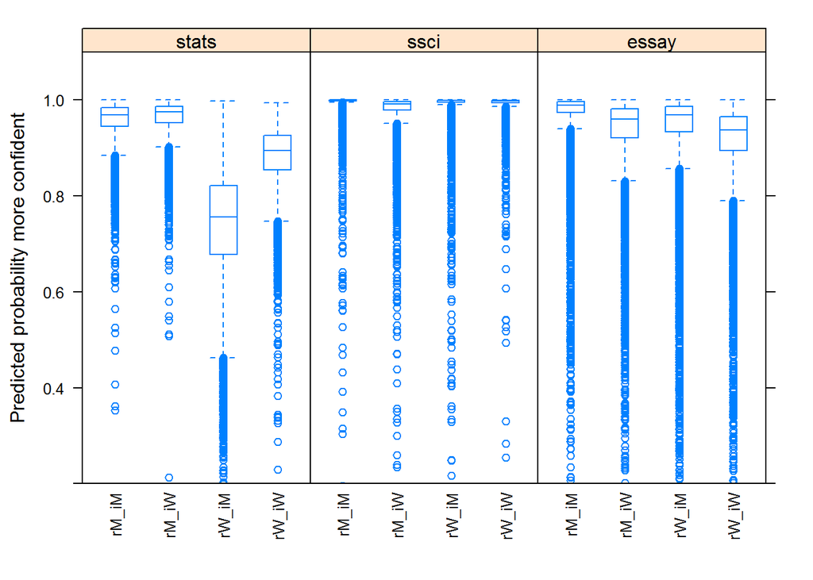

```r
pred <- data.table(
    rM_iM1 = m1.1$Sol[,1],
    rM_iW1 = m1.1$Sol[,1] + m1.1$Sol[,3],
    rW_iM1 = m1.1$Sol[,1] + m1.1$Sol[,2],
    rW_iW1 = m1.1$Sol[,1] + m1.1$Sol[,2] + m1.1$Sol[,3] + m1.1$Sol[,4],
    rM_iM2 = m2.1$Sol[,1],
    rM_iW2 = m2.1$Sol[,1] + m2.1$Sol[,3],
    rW_iM2 = m2.1$Sol[,1] + m2.1$Sol[,2],
    rW_iW2 = m2.1$Sol[,1] + m2.1$Sol[,2] + m2.1$Sol[,3] + m2.1$Sol[,4],
    rM_iM3 = m3.1$Sol[,1],
    rM_iW3 = m3.1$Sol[,1] + m3.1$Sol[,3],
    rW_iM3 = m3.1$Sol[,1] + m3.1$Sol[,2],
    rW_iW3 = m3.1$Sol[,1] + m3.1$Sol[,2] + m3.1$Sol[,3] + m3.1$Sol[,4]
)

pred <- melt(pred, measure.vars=names(pred))
pred$value <- pnorm(pred$value)

pred$variable <- substr(pred$variable, 1, 5)

pred$type <- c(rep("stats",length(m1.1$Sol)),rep("ssci",length(m2.1$Sol)),rep("essay",length(m3.1$Sol)))
pred$type <- factor(pred$type, levels=c("stats","ssci","essay"))

bwplot(value ~ variable|type, pred, pch="|", ylim=c(.2,1.1), layout=c(3,1), scales = list(x = list(relation = 'free',rot=90)),ylab="Predicted probability more confident")
```

- Further notes: interestingly, variation across 5 lab groups is largest on essay writing confidence. This group-level variance components is predicted to be 2–4 % on the other two, suggesting that even if instructor gender is treated substantively significant, it may explain up to a limited portion of variation across groups.

```r
round(c(quantile(m1.1$VCV[,1],probs=.5),quantile(m2.1$VCV[,1],probs=.5),quantile(m3.1$VCV[,1],probs=.5)),2)
```

```
##  50%  50%  50%
## 0.02 0.04 0.30
```

- Below the model summaries: ++ DV statistics module confidence:

```r
summary(m1.1)
```

```
##
##  Iterations = 3001:20000
##  Thinning interval  = 1
##  Sample size  = 17000
##
##  DIC: 220.3671
##
##  G-structure:  ~instructor
##
##            post.mean  l-95% CI u-95% CI eff.samp
## instructor   0.07076 0.0003363   0.2549     6081
##
##  R-structure:  ~units
##
##       post.mean l-95% CI u-95% CI eff.samp
## units         1        1        1        0
##
##  Location effects: stats ~ 1 + factor(gender) * factor(instructor_gender)
##
##                                            post.mean l-95% CI u-95% CI eff.samp    pMCMC
## (Intercept)                                  1.87211  1.02788  2.66606     1173 0.000471 ***
## factor(gender)2                             -1.18446 -2.03322 -0.32575     1763 0.007176 **
## factor(instructor_gender)2                   0.08046 -0.87919  1.12301     2486 0.872824
## factor(gender)2:factor(instructor_gender)2   0.48270 -0.62971  1.55011     2408 0.390000
## ---
## Signif. codes:  0 '***' 0.001 '**' 0.01 '*' 0.05 '.' 0.1 ' ' 1
##
##  Cutpoints:
##                       post.mean l-95% CI u-95% CI eff.samp
## cutpoint.traitstats.1     1.928    1.515    2.396    602.3
## cutpoint.traitstats.2     5.158    3.927    6.577    310.6
```

++ DV social science course confidence:

```r
summary(m2.1)
```

```
##
##  Iterations = 3001:20000
##  Thinning interval  = 1
##  Sample size  = 17000
##
##  DIC: 159.6647
##
##  G-structure:  ~instructor
##
##            post.mean  l-95% CI u-95% CI eff.samp
## instructor    0.2292 0.0003443   0.8298     1414
##
##  R-structure:  ~units
##
##       post.mean l-95% CI u-95% CI eff.samp
## units         1        1        1        0
##
##  Location effects: ssci ~ 1 + factor(gender) * factor(instructor_gender)
##
##                                            post.mean l-95% CI u-95% CI eff.samp   pMCMC
## (Intercept)                                   3.2342   2.1201   4.3889    313.8 0.00129 **
## factor(gender)2                              -0.2829  -1.1658   0.6356   1860.6 0.52682
## factor(instructor_gender)2                   -0.8603  -2.0386   0.2401   2253.4 0.12929
## factor(gender)2:factor(instructor_gender)2    0.7057  -0.4966   1.8847   1802.1 0.24071
## ---
## Signif. codes:  0 '***' 0.001 '**' 0.01 '*' 0.05 '.' 0.1 ' ' 1
##
##  Cutpoints:
##                      post.mean l-95% CI u-95% CI eff.samp
## cutpoint.traitssci.1     2.015    1.300    2.741    126.1
## cutpoint.traitssci.2     5.778    4.786    6.834    178.1
```

++ DV essay skills confidence:

```r
summary(m3.1)
```

```
##
##  Iterations = 3001:20000
##  Thinning interval  = 1
##  Sample size  = 17000
##
##  DIC: 216.7166
##
##  G-structure:  ~instructor
##
##            post.mean  l-95% CI u-95% CI eff.samp
## instructor    0.6778 0.0003266    2.366     4204
##
##  R-structure:  ~units
##
##       post.mean l-95% CI u-95% CI eff.samp
## units         1        1        1        0
##
##  Location effects: essay ~ 1 + factor(gender) * factor(instructor_gender)
##
##                                            post.mean l-95% CI u-95% CI eff.samp   pMCMC
## (Intercept)                                   2.2813   1.0484   3.4782     1852 0.00847 **
## factor(gender)2                              -0.4502  -1.2867   0.3833     2281 0.29341
## factor(instructor_gender)2                   -0.5422  -1.8991   0.8676     4537 0.39224
## factor(gender)2:factor(instructor_gender)2    0.2338  -0.8276   1.3746     2309 0.67894
## ---
## Signif. codes:  0 '***' 0.001 '**' 0.01 '*' 0.05 '.' 0.1 ' ' 1
##
##  Cutpoints:
##                       post.mean l-95% CI u-95% CI eff.samp
## cutpoint.traitessay.1     2.069    1.631    2.574    389.4
## cutpoint.traitessay.2     4.891    4.065    5.835    428.1
```

## Tweaked/extended models.

Later, it will be worth exploring: **(a)** if inclusion of the extremes on the dependent variable, given they’re missing in some groups, may impact these results and re-run models dichotomised b/w confident and not confident; **(b)** controlling for math grades.

I did run the stats confidence model controlling for maths, not much changes:

```r
d <- d[!is.na(math),,] # can't have missing data in fixed predictors

prior<-list(
B=list(mu=c(0,0,0,0,0), V=gelman.prior(~factor(gender)*factor(instructor_gender)+math, data=d, scale=sqrt(1+1))),
R=list(V=1,fix=1),
G=list(G1=list(V=2,nu=.002))
)

m1.2 <- MCMCglmm(fixed=stats ~ 1 + factor(gender) * factor(instructor_gender) + math, random=~instructor, prior = prior, data=d, family="ordinal", nitt=20000, thin=1)
```

```r
summary(m1.2)
```

```
##
##  Iterations = 3001:20000
##  Thinning interval  = 1
##  Sample size  = 17000
##
##  DIC: 213.988
##
##  G-structure:  ~instructor
##
##            post.mean  l-95% CI u-95% CI eff.samp
## instructor   0.06909 0.0002435   0.2569     5372
##
##  R-structure:  ~units
##
##       post.mean l-95% CI u-95% CI eff.samp
## units         1        1        1        0
##
##  Location effects: stats ~ 1 + factor(gender) * factor(instructor_gender) + math
##
##                                            post.mean l-95% CI u-95% CI eff.samp    pMCMC
## (Intercept)                                   2.1852   1.1602   3.1832     1101 0.000471 ***
## factor(gender)2                              -1.0769  -1.9541  -0.2211     1946 0.012353 *
## factor(instructor_gender)2                    0.2306  -0.7902   1.2011     2709 0.642118
## math                                         -0.1910  -0.4791   0.0955     1934 0.199765
## factor(gender)2:factor(instructor_gender)2    0.3454  -0.7786   1.4323     2267 0.538824
## ---
## Signif. codes:  0 '***' 0.001 '**' 0.01 '*' 0.05 '.' 0.1 ' ' 1
##
##  Cutpoints:
##                       post.mean l-95% CI u-95% CI eff.samp
## cutpoint.traitstats.1     1.939    1.471    2.384    483.8
## cutpoint.traitstats.2     5.170    3.978    6.594    376.8
```